# Predicting Velocity with Force Plates: Can Lower Body Forces predict Velocity on the Mound?

### Final Model - Random Forest

```r
set.seed(208)
final_forest <- ranger(formula = velocity ~ .,
                      data = baked_train_fp,
                      num.trees = 500,
                      mtry = randomforest$bestTune$mtry,
                      splitrule = "variance",
                      min.node.size = 2,
                      importance = "impurity")

final_predictions <- predict(final_forest, data = baked_test_fp, type = "response")

FinalRMSE <- sqrt(mean((final_predictions$predictions - baked_test_fp$velocity)^2))
FinalRMSE
```

```
## [1] 6.311047
```

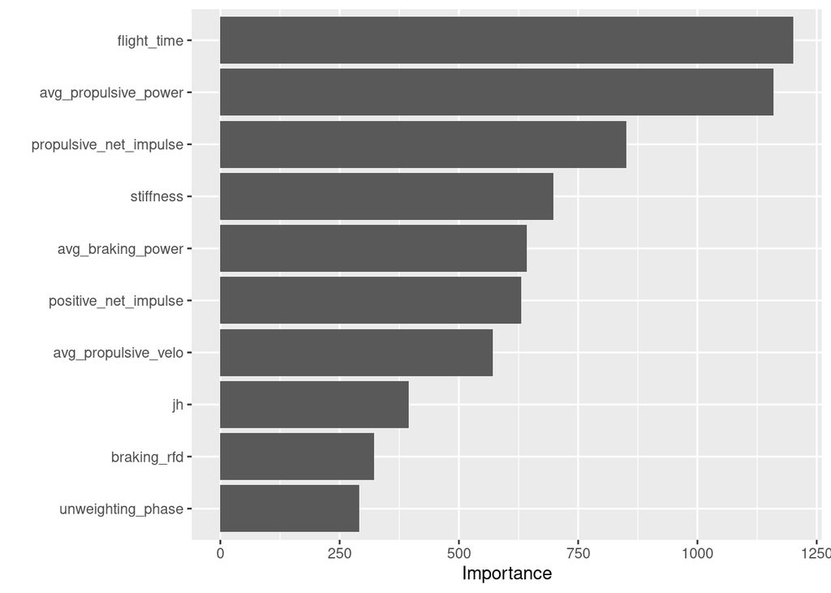

```r
vip(final_forest, num_features = 10)
```

*Training Results*

[output not shown]

*Test Results*

| Technique | Optimal RMSE Value |
| --- | --- |
| Random Forest | 6.311047 |

## Conclusion

Looking at the variable importance plot for the final model, a couple key takeaways that are applicable in training can be found. I will be covering the top 7 here, as the rest of the variables show significantly lower importance values. First, there is a relatively sharp drop-off after the first two (flight time and avg propulsive power). This indicates that these two variables are not only of highest importance; it’s by a solid margin. Flight time relates directly to overall jump execution encompassing many factors of the jump; it is not suprising that is contributes heavily to velocity. Propulsive power can be better understood considering propulsive net impulse is the third highest importance. Together with average power, these variables point to the momentum and overall energy output during the moment of change from loading to pushing away from the ground (straight up in this case, sideways and down in the case of throwing) are key in training the body to be able to throw harder. The next two variables come from the braking phase; stiffness and average power. This follows the previous logic; if the propuslive impulse, or force over period of time away from the ground, is important in throwing harder, the opposite reaction to that force, stiffness (force generated per unit of downward movement), would also be key. Positive net impulse is next; it reflects the total vertical push available after overcoming body weight and counter movement, a key point in the throw as well. This “extra” force beyond the initial movement and body weight is indicative of the many elements of the switch between deceleration and acceleration, where excess force is needed to speed up the arm and subsequent throw. Finally, propulsive velocity is the 7th most important variable backing up the implications seen from the propulsive phase as a whole and high importance of maximizing output (and speed) during the acceleration phase of training movements.

Together with the final model, this analysis proved useful in gaining more understanding about the relationship of force plate metrics with pitching velocity. The results are still too inaccurate for assessment use (that is, predicting velocity from an input of force plate numbers) but do serve as a stepping point to keep building a more advanced model. In the future, I will make a couple key changes. First, including some history of injury would be helpful and important in the context of prediction. I would also like to see a revamp of the data; potentially an updated set of *average* jumps that updates with new data input and a broader scope of athletes (~500-700). There is a possibility of also inlcuding other jump metrics. As the counter movement jump is strong in assessing propulsive and braking forces others like the multi-rebound give a better perspective on elasticity and prolonged force output. These in turn could strengthen the model, and with more variables we could further reduce the high correlations between predictors.

## Citations/References

*https://yutannihilation.github.io/allYourFigureAreBelongToUs/ggthemes/*

*https://www.hawkindynamics.com/hawkin-metric-database*